# 2016 Presidential Election Contributions in Ohio by Jamie Brand

# Dataset

### Candidate Names (cand_nm)

```
##
##             Jindal, Bobby    Perry, James R. (Rick)
##                         1                         1
##         Pataki, George E.   O'Malley, Martin Joseph
##                         2                         5
##      Santorum, Richard J.            Huckabee, Mike
##                         5                         6
##        Graham, Lindsey O.            Fiorina, Carly
##                         7                        15
##                 Bush, Jeb   CRUZ, RAFAEL EDWARD TED
##                        26                        40
##                Paul, Rand          Sanders, Bernard
##                       203                       238
##              Rubio, Marco Cruz, Rafael Edward 'Ted'
##                       239                       483
##       Carson, Benjamin S.   Clinton, Hillary Rodham
##                       516                       665
```

There is a duplicate factor here with “CRUZ, RAFAEL EDWARD TED”. I changed each instance of it to “Cruz, Rafael Edward ‘Ted’” to match the rest of the dataset.

### Candidate Id, File Number, and FILER ID. (cand_id,file_nm and cmte_id)

```
##
##             Jindal, Bobby    Perry, James R. (Rick)
##                         1                         1
##         Pataki, George E.   O'Malley, Martin Joseph
##                         2                         5
##      Santorum, Richard J.            Huckabee, Mike
##                         5                         6
##        Graham, Lindsey O.            Fiorina, Carly
##                         7                        15
##                 Bush, Jeb                Paul, Rand
##                        26                       203
##          Sanders, Bernard              Rubio, Marco
##                       238                       239
##       Carson, Benjamin S. Cruz, Rafael Edward 'Ted'
##                       516                       523
##   Clinton, Hillary Rodham
##                       665
```

```
##
## P20003281 P60008398 P60007572 P20002721 P60007671 P80003478 P60007697
##         1         1         2         5         5         6         7
## P60007242 P60008059 P40003576 P60007168 P60006723 P60005915 P60006111
##        15        26       203       238       239       516       523
## P00003392
##       665
```

```
##
## 1014598 1014957 1015617 1015257 1015715 1015311 1015713 1015551 1015075
##       1       1       2       5       5       6       7      15      26
## 1003942 1004025 1015683 1015044 1015697 1015538 1015509 1015585
##      28      40     203     238     239     483     488     665
```

```
##
## C00500587 C00580159 C00578245 C00578492 C00578658 C00577981 C00578757
##         1         1         2         5         5         6         7
## C00577312 C00579458 C00575449 C00577130 C00458844 C00573519 C00574624
##        15        26       203       238       239       516       523
## C00575795
##       665
```

### Contributor state (contbr_st)

```
##
##   OH
## 2452
```

No need to keep the contrbr_st features as it refers to the state which is the same throughout this dataset.

### Election type (election_tp)

```
##
## G2016 P2016
##    19  2433
```

Values of G2016 Appear to be contributions which have been reassigned (see Receipt_desc feature)

### Reciept description (reciept_desc)

```
##
##
##                                                                          2421
##                           REATTRIBUTION / REDESIGNATION REQUESTED (AUTOMATIC)
##                                                                             4
## REATTRIBUTION / REDESIGNATION REQUESTED (AUTOMATIC) REATTRIBUTION FROM SPOUSE
##                                                                             1
##                                                       REATTRIBUTION TO SPOUSE
##                                                                             1
##                                                    REDESIGNATION FROM PRIMARY
##                                                                             7
##                                             REDESIGNATION FROM SENATE GENERAL
##                                                                             2
##                                                      REDESIGNATION TO GENERAL
##                                                                             7
##                                         REDESIGNATION TO PRESIDENTIAL GENERAL
##                                                                             2
##                                                                        Refund
##                                                                             6
##                                                             SEE REATTRIBUTION
##                                                                             1
```

Details of reattribution or redesignation.

### Memo code (memo_cd)

```
##
##         X
## 2385   67
```

According to : http://www.fec.gov/finance/disclosure/metadata/DataDictionaryContributionsbyIndividuals.shtml X’ indicates that the amount is NOT to be included in the itemization total.

### Memo text (memo_text)

```
##
##
##                                                                          2147
##                                                                             *
##                                                                             1
##                                                                  CHARGED BACK
##                                                                             1
##                                           CHARGED BACK $1000.00 ON 03/09/2015
##                                                                             1
##                                           * EARMARKED CONTRIBUTION: SEE BELOW
##                                                                           205
##                                                 EARMARKED FROM MAKE DC LISTEN
##                                                                            66
##                           REATTRIBUTION / REDESIGNATION REQUESTED (AUTOMATIC)
##                                                                             4
## REATTRIBUTION / REDESIGNATION REQUESTED (AUTOMATIC) REATTRIBUTION FROM SPOUSE
##                                                                             1
##                                                       REATTRIBUTION TO SPOUSE
##                                                                             1
##                                                    REDESIGNATION FROM PRIMARY
##                                                                             7
##                                             REDESIGNATION FROM SENATE GENERAL
##                                                                             2
##                                                      REDESIGNATION TO GENERAL
##                                                                             7
##                                         REDESIGNATION TO PRESIDENTIAL GENERAL
##                                                                             2
##                                                               SEE ATTRIBUTION
##                                                                             1
##                                                             SEE REATTRIBUTION
##                                                                             1
##                                                   TRANSFER FROM RUBIO VICTORY
##                                                                             5
```

Memo_text feature: Approximately 10% of contributions are earmarked contributions.

### Transaction id (tran_id)

The transaction id features was removed as it contains no useful information.

### Receipt Date (contb_receipt_date)

```
##         Min.      1st Qu.       Median         Mean      3rd Qu.
## "2014-07-17" "2015-05-01" "2015-05-21" "2015-05-20" "2015-06-18"
##         Max.
## "2015-06-30"
```

Data needed to be changed from string to date format.

### Postcode (contbr_zip)

```
##
## 43004 43015 43016 43017 43021 43022 43026 43031 43035 43050 43054 43055
##     4     5    11     9    22     3     6     7     3     4    14    10
## 43062 43065 43068 43074 43076 43078 43081 43082 43085 43105 43107 43110
##     1    26     2     9     1     1    14     7    16     1     2     6
## 43112 43119 43123 43125 43130 43143 43146 43147 43201 43202 43204 43205
##     4    17    14     4    13     2     1    31    13     7     1    10
## 43206 43207 43209 43212 43213 43214 43215 43216 43219 43220 43221 43224
##    10     2    30     8     5    23    16     2     6    25    27     4
## 43230 43232 43235 43311 43315 43318 43319 43326 43331 43334 43348 43351
##    18     3    34     3     2     1     1     1     2     5     1     1
## 43357 43402 43416 43420 43512 43528 43532 43537 43545 43551 43555 43560
##     3     1     2    10     2    11     6    18     7    13     2     9
## 43566 43567 43605 43606 43607 43613 43614 43615 43617 43619 43623 43701
##     8     2     1     8    15     2     3    19     4     2     4     4
```

[output cut: 52 more lines]

The zip codes were reduced to the area zip code (the first 5 characters) as the nine figure numbers have too much detail for this analysis.

### Form type (form_tp)

```
##
## SA17A  SA18 SB28A
##  2401    45     6
```

The form_tp factor levels refer to the following:

- SA17A = Contribution from individuals other than political orgnaisations
- SA18 = Transfers from other authorized commitees
- SA28A = Refunds to individuals other than political orgnaisations

As shown on this form: http://www.fec.gov/finance/disclosure/metadata/DataDictionaryTransactionTypeCodes.shtml

### Additional Candidate Information

```
##                         Name Age Gender       Party Running_Since
## 1              Jindal, Bobby  44      M  Republican       24-6-15
## 2     Perry, James R. (Rick)  65      M  Republican        4-6-15
## 3          Pataki, George E.  70      M  Republican       28-5-15
## 4    O'Malley, Martin Joseph  52      M  Democratic       30-5-15
## 5       Santorum, Richard J.  57      M  Republican       27-5-15
## 6             Huckabee, Mike  59      M  Republican        5-5-15
## 7         Graham, Lindsey O.  60      M  Republican        1-6-15
## 8             Fiorina, Carly  60      F  Republican        4-5-15
## 9                  Bush, Jeb  62      M  Republican       15-6-15
## 10                Paul, Rand  52      M  Republican        7-4-15
## 11          Sanders, Bernard  73      M Independent       26-5-15
## 12              Rubio, Marco  44      M  Republican       13-4-15
## 13       Carson, Benjamin S.  63      M  Republican        3-5-15
## 14 Cruz, Rafael Edward 'Ted'  44      M  Republican       23-3-15
## 15   Clinton, Hillary Rodham  67      F  Democratic       12-4-15
```

As there are not a huge number of candidates I manually collated extra data about each of them in an csv file. These were added as features in the main dataset.

### Predicted Contributor Gender (contbr_gender)

A predicted gender of contributor feature was created based on the contributors first name.

It was made with a free csv file of first names with genders from: http://tedwise.com/2011/02/08/check-the-gender-of-a-first-name

```
##
##    F    M
##  934 1396
```

### Summary of dataset

```
##    cand_nm                          contbr_nm        contbr_city
##  Length:2452        GERBEC, JAYSON       :  22   CINCINNATI: 256
##  Class :character   SHALE, R. ANNE MS.   :  19   COLUMBUS  : 231
##  Mode  :character   BRIONES, BERTA       :  17   CLEVELAND :  82
##                     AMBROSE, JOHN ANTHONY:  16   TOLEDO    :  52
##                     SLADEK, PATRICIA     :  16   AKRON     :  45
##                     HALL, RYAN           :  15   DAYTON    :  37
##                     (Other)              :2347   (Other)   :1749
##   contbr_zip                                      contbr_employer
##  Length:2452        RETIRED                               : 529
##  Class :character   N/A                                   : 140
##  Mode  :character   INFORMATION REQUESTED PER BEST EFFORTS: 127
##                     SELF-EMPLOYED                         : 123
##                     NOT EMPLOYED                          :  92
##                     INFORMATION REQUESTED                 :  53
##                     (Other)                               :1388
##                               contbr_occupation contb_receipt_amt
##  RETIRED                               : 638    Min.   :-2700.0
##  INFORMATION REQUESTED PER BEST EFFORTS: 117    1st Qu.:   45.0
##  ATTORNEY                              :  86    Median :  100.0
##  PHYSICIAN                             :  78    Mean   :  324.9
##  NOT EMPLOYED                          :  62    3rd Qu.:  250.0
##  HOMEMAKER                             :  59    Max.   : 5400.0
##  (Other)                               :1412
##  contb_receipt_dt
##  Min.   :2014-07-17
##  1st Qu.:2015-05-01
##  Median :2015-05-21
##  Mean   :2015-05-20
##  3rd Qu.:2015-06-18
##  Max.   :2015-06-30
##
##                                               receipt_desc  memo_cd
##                                                     :2421    :2385
##  REDESIGNATION FROM PRIMARY                         :   7   X:  67
##  REDESIGNATION TO GENERAL                           :   7
##  Refund                                             :   6
##  REATTRIBUTION / REDESIGNATION REQUESTED (AUTOMATIC):   4
##  REDESIGNATION FROM SENATE GENERAL                  :   2
##  (Other)                                            :   5
```

[output cut: 9 more lines]

```
##  Min.   :44.00   F: 680      Democratic : 670   Min.   :2015-03-23
##  1st Qu.:44.00   M:1772      Independent: 238   1st Qu.:2015-04-07
##  Median :63.00               Republican :1544   Median :2015-04-12
##  Mean   :58.16                                  Mean   :2015-04-17
##  3rd Qu.:67.00                                  3rd Qu.:2015-05-03
##  Max.   :73.00                                  Max.   :2015-06-24
##
##  contbr_gender
##  F   : 934
##  M   :1396
##  NA's: 122
##
##
##
##
```

```
## [1] 2452   18
```

# Univariate Plots Section

### Distribution of contribution amounts

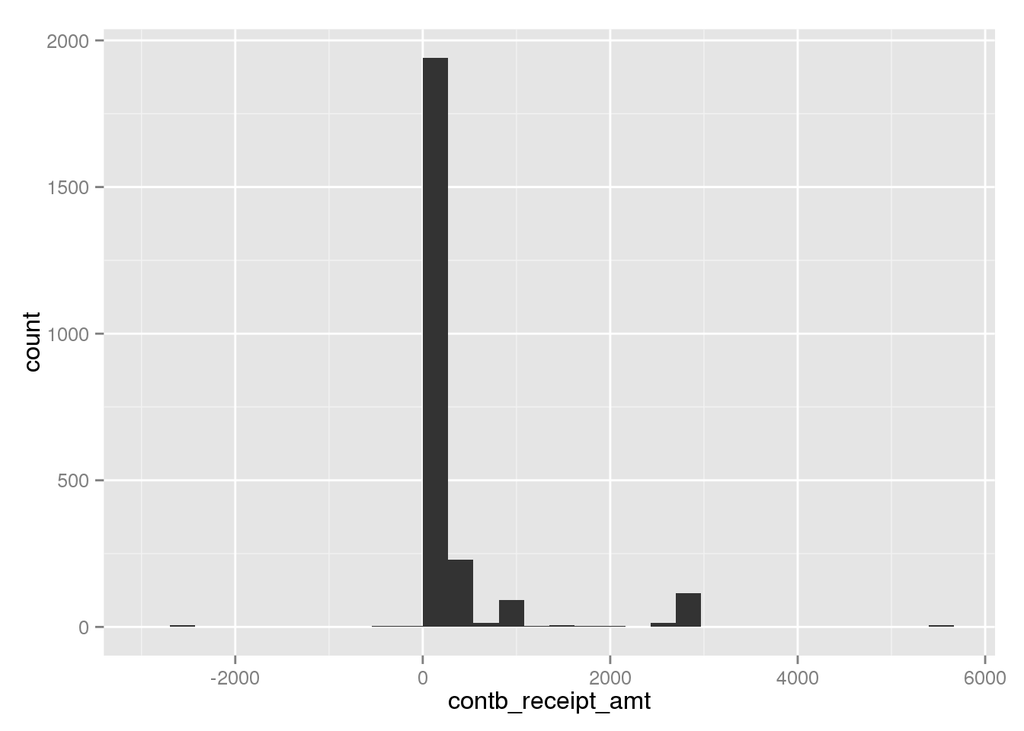

We can see there are a number of outliers on either side of the distribution. The negative values are from refunds / redesignation of donations. We can focus on the area between 0 and 1500 dollars for more detail

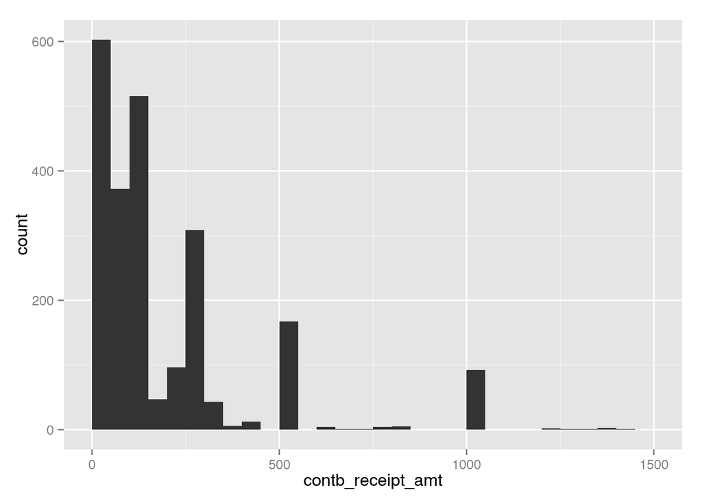

And on contributions between 0 and 500 dollars

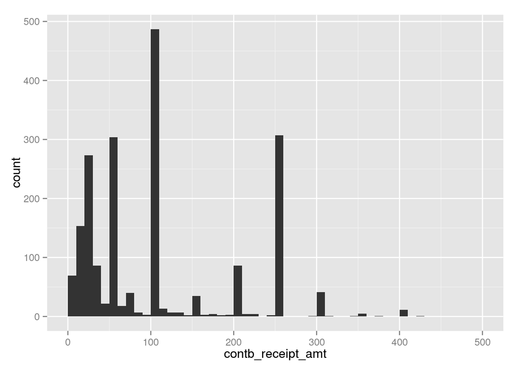

Here we see an interesting tendency that people have to donate in ‘round’ numbers, with peaks at $50 dollar intervals.

### When were the contributions made?

It is still near the beginning of the campaigns so we can see that the number of contributions began to rise in April 2015. I expect the number of donations will continue to rise as the campaigns continue.

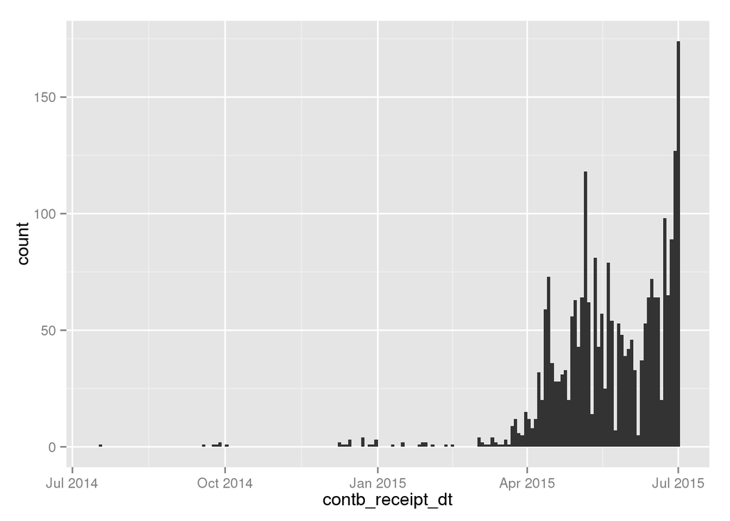

### Contributions by candidate

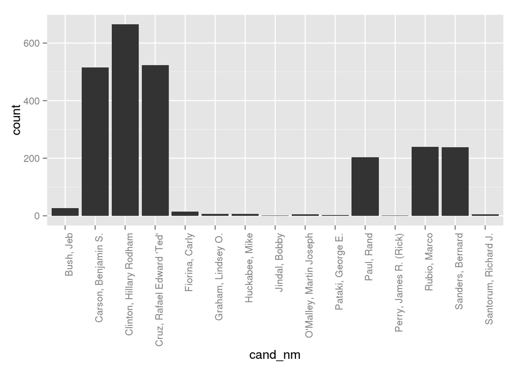

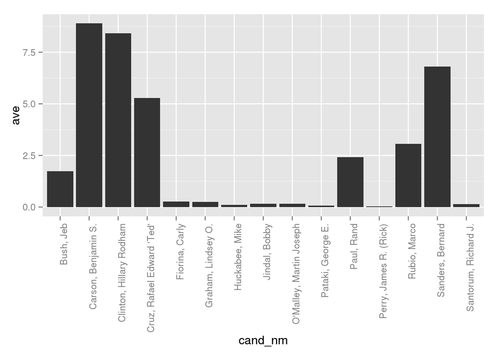

This plot is visually similar to the total number of contributions made by candidate. While obviously we should be aware of the different starting dates for the candidates, this plot implies that it does not have a strong effect on the number of contributions made. I suspect a reason for this may be that were aware that candidates were going to announce they were running before the announcements came.

### Candidates by Political party

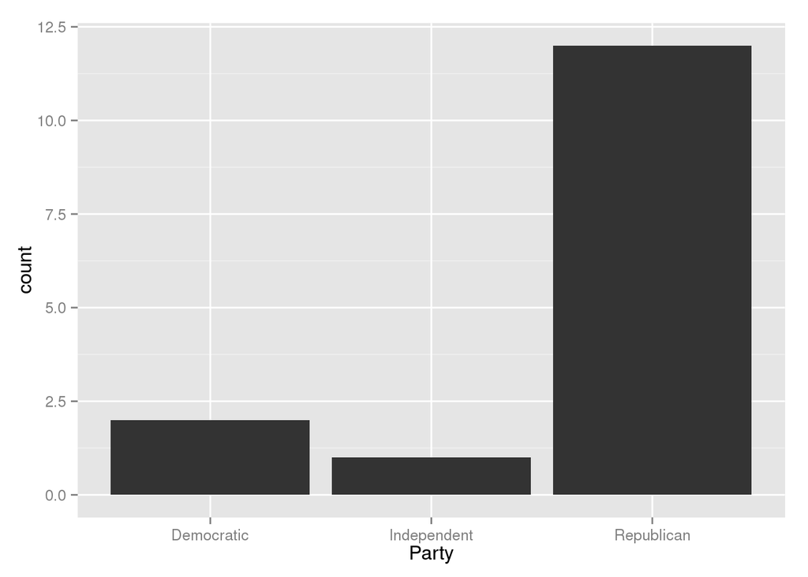

Clearly there are more candidates for the republican party by a wide margin. We can see from the previous plot of contributions by candidate that a number of candidates have had a very low number of contributions.

### Contibutions by Political party

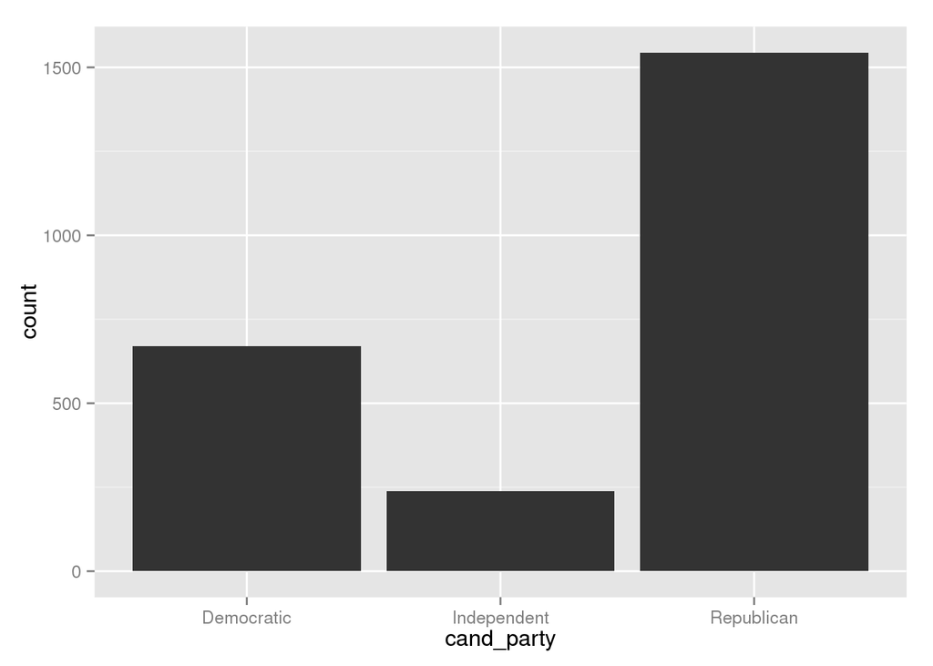

There is a much larger number of contributions to the republican party than the other parties. However, as we have already ascertained, there are more candidates for the republican party. This seems to imply that Democratic candidates (and the Independent candidate) are getting more contributions each on average.

### Candidates by Age

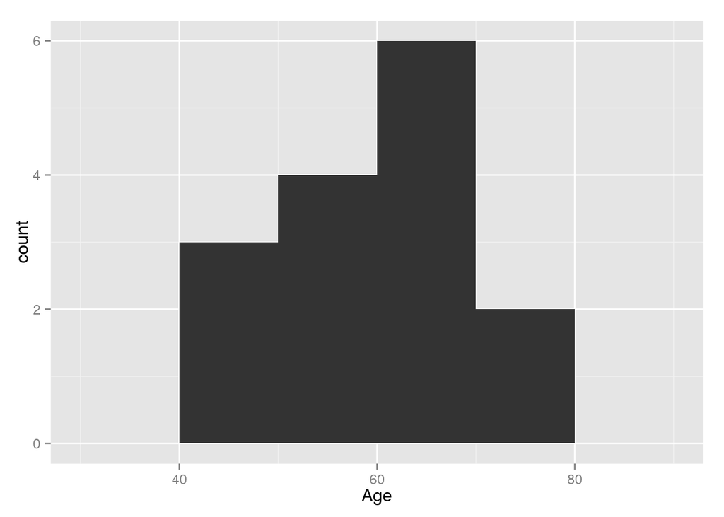

This gives us a nice idea of the distribution of ages.

### Contibutions by Age of candidate

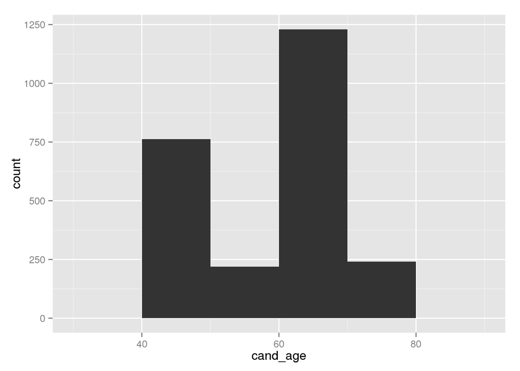

This seems to show a very unusual relation ship between the age of the candidate and the number of contributions made. However, it is likely to be a result of only a relatively small number of candidates with a wide range of support. We can change the binsize to see if the relationship still appears.

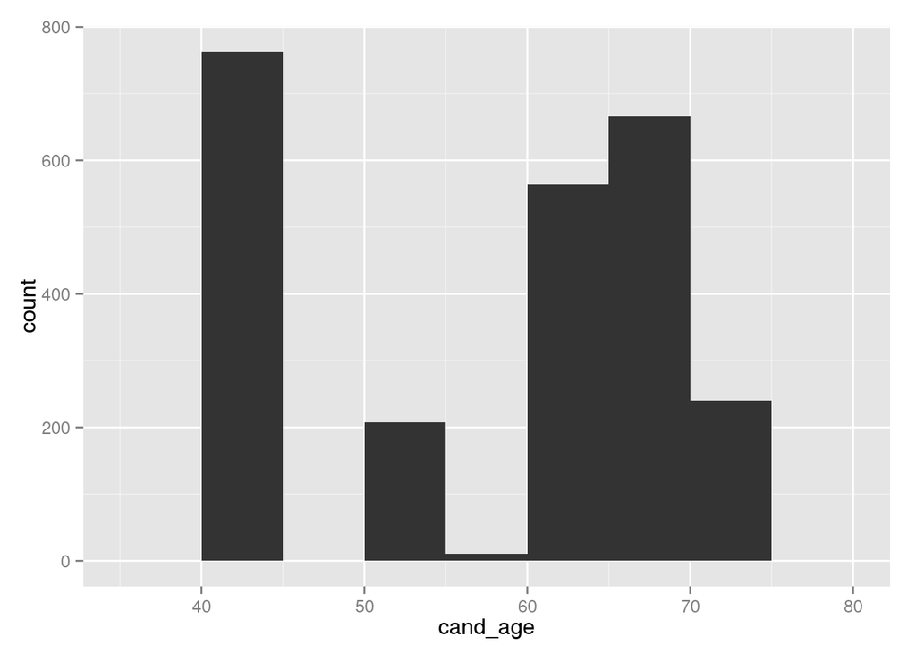

In the second plot there is still an unusual distribution so perhaps this is something we can look at later.

### Contributions by city

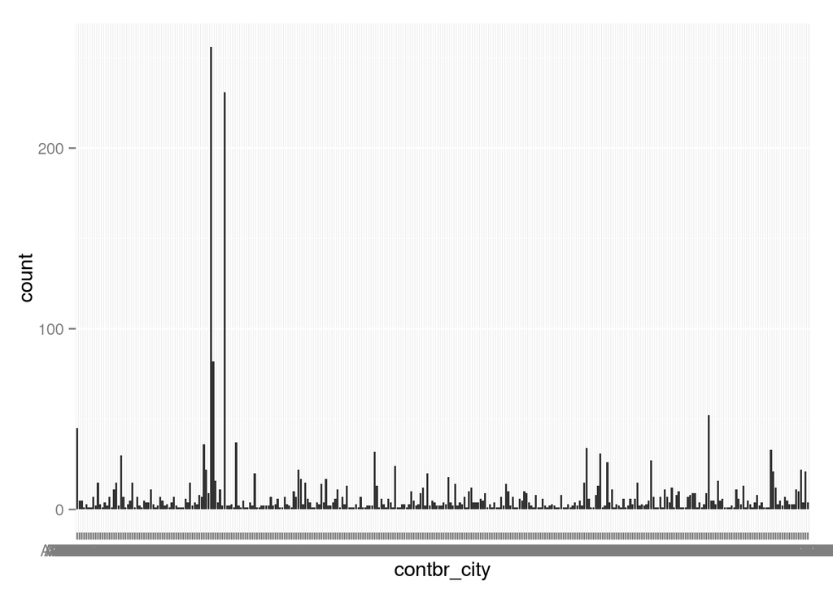

This is difficult to read. Repeat with only the top twenty five cities.

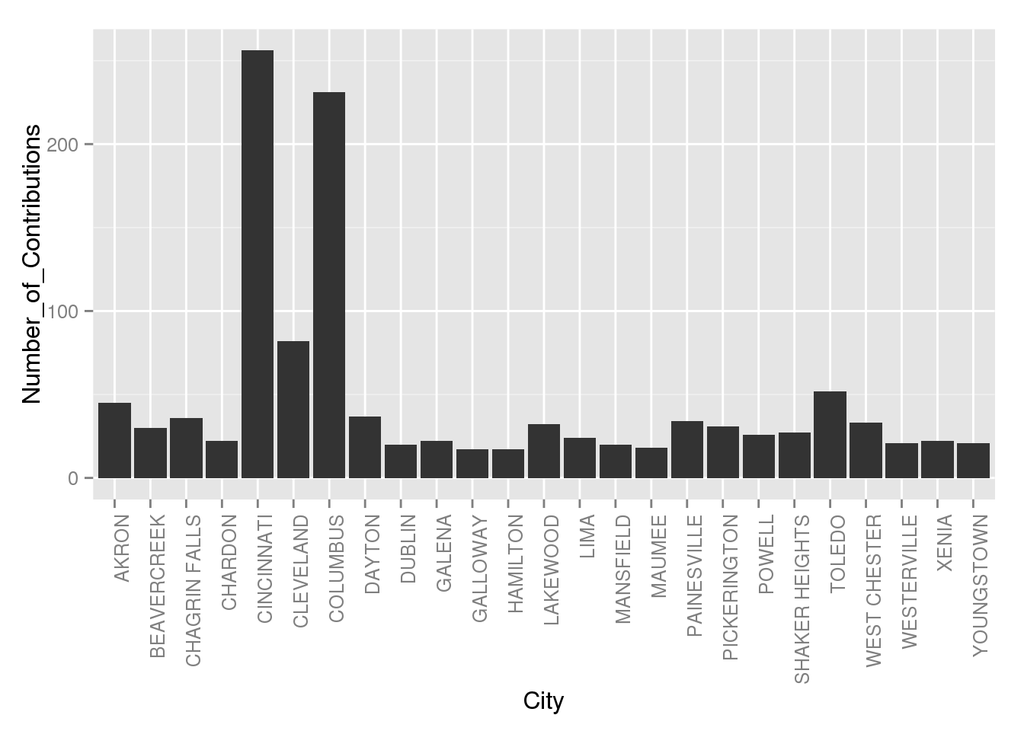

We can see that Cincinatti and Columbus are making the largest number of contributions. This still tells us nothing about the amounts contributed though.

### Contributions by occupation

We know there are a lot of occupations so lets limit it to the top 25.

```
##
##                                RETIRED
##                                    638
## INFORMATION REQUESTED PER BEST EFFORTS
##                                    117
##                               ATTORNEY
##                                     86
##                              PHYSICIAN
##                                     78
##                           NOT EMPLOYED
##                                     62
##                              HOMEMAKER
##                                     59
##                  INFORMATION REQUESTED
##                                     57
##                                  OWNER
##                                     47
##                               ENGINEER
##                                     44
##                                  SALES
##                                     43
##                              PROFESSOR
##                                     42
##                                TEACHER
##                                     24
##                             CONSULTANT
##                                     22
##                              EXECUTIVE
##                                     21
##                             ACCOUNTANT
##                                     20
##                              PRESIDENT
##                                     20
##                                MANAGER
##                                     19
##                        PROGRAM MANAGER
##                                     18
##                          SELF EMPLOYED
##                                     18
##                               DISABLED
##                                     17
##                                 BANKER
##                                     16
##                         BUSINESS OWNER
##                                     16
##                                    CEO
##                                     16
##                                 PACKER
##                                     16
##                       PFRESH ASSISTANT
##                                     13
```

Lets remove the ‘Information Requested’ factors as they tell us nothing.

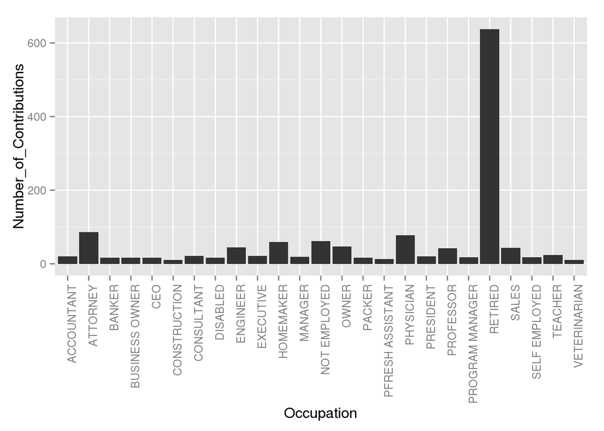

Obviously the most contributions are made by retired people by a very wide margin. It’s worth noting that some occupations overlap. For instance ‘owner’ and ‘business owner’ refer more or less to the same thing. Other ambigious job titles are ‘consultant’ and ‘executive’ which both have a wide range of possible meanings. The ‘pfresh assistant’ job title confused me but a little research showed it was a specific position at ‘Target’.

### Contributions by employer

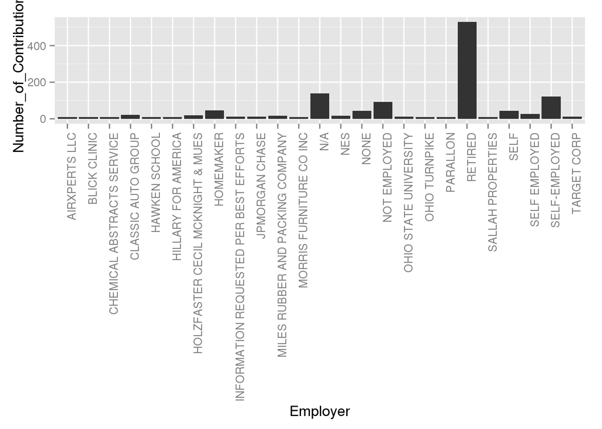

We can see that ‘Target Corp’ is one of the top employers, explaining the ‘pfresh assistant’ job title from the previous plot. I imagine that certain companies encourge their employees to make donations in a certain manner so it will be interesting to look at which party different company’s employees are contributing to.

### Multiple Contributions

Does anyone contribute more than once? Who are the top contributors

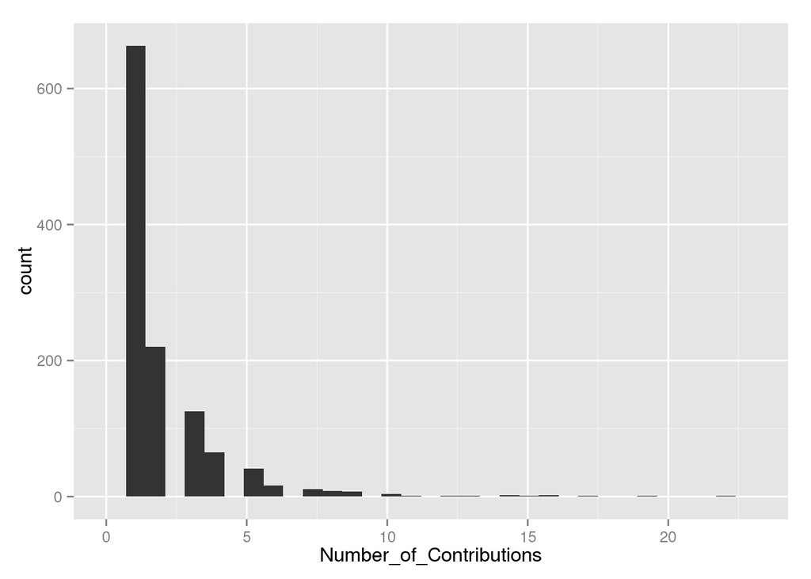

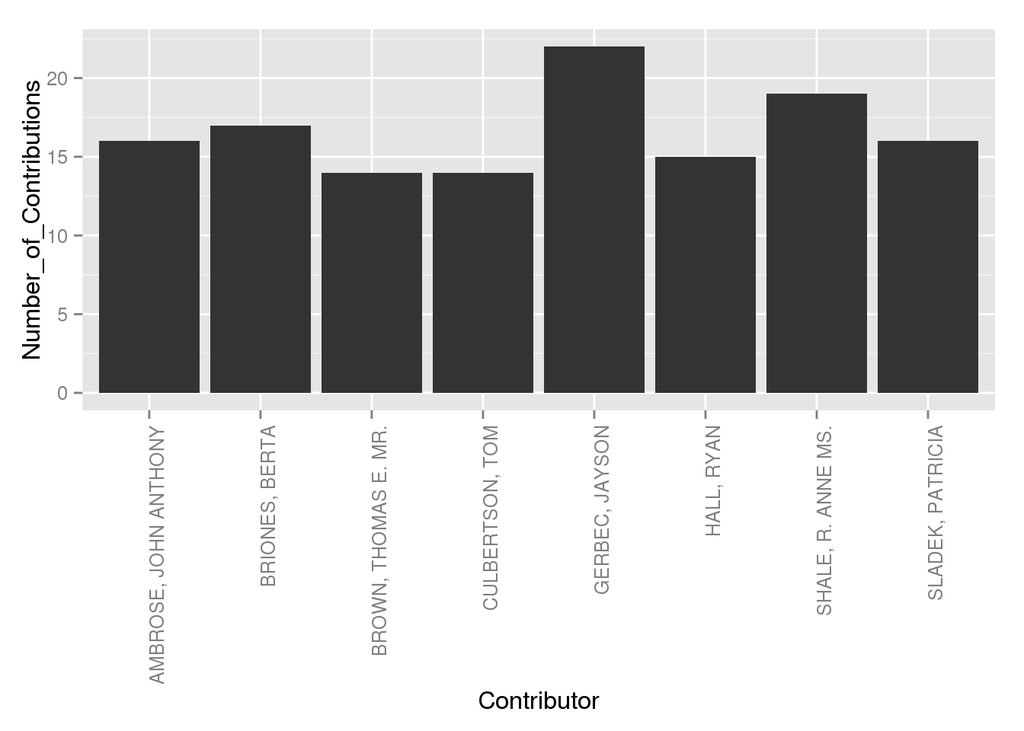

We can see that, while most people have only made one contribution a number have made multiple contributions.

# Univariate Analysis

### What is/are the main feature(s) of interest in your dataset?

The features of interest are the candidate names and their political parties. I hope to look at who is voting for which candidate / party and find any patterns in ‘how’ they vote. For instance, do contributors to one party make higher or lower contributions than contributors to the other.

### What other features in the dataset do you think will help support your investigation into your feature(s) of interest?

I will be interested to see how the candidate chosen varies with the occupation and employer of the contributor. I expect different candidates may be more or less popular depending on the area the contributor is for at a city or postcode level.

### Did you create any new variables from existing variables in the dataset?

I was worried that the date the candidates announced their campaign could have had an effect on the number of contributions they had. To check this I compared a bar plot of the number of contributions each candidate had with a bar plot of the average number of contributions per day for each candidate. I manually create a csv file with details of each candidate which was used to create the candidate age, party and gender. I also created a predicted gender feature for the contributors. While this is cannot be expected to be completely accurate, and has produced missing values, it will by useful for looking for differences in the way different genders contribute.

### Of the features you investigated, were there any unusual distributions? Did you perform any operations on the data to tidy, adjust, or change the form of the data? If so, why did you do this?

# Bivariate Plots Section

### Contribution amount by candidate

Who has recieved the highest total of contributions so far?

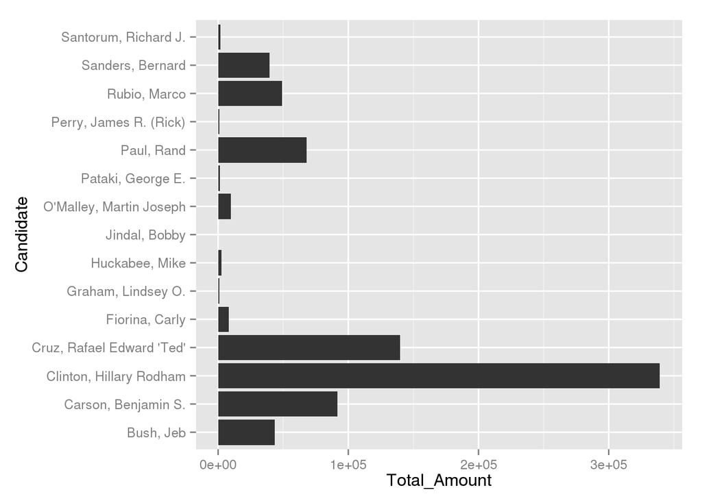

Hilary Clinton has received the highest amount in contributions so far. The plot here shows seven of the candidates getting much more in contributions than the others. This mirrors the plot in the previous section showing number of contributions by candidate.

Which candidates are getting the largest donations?

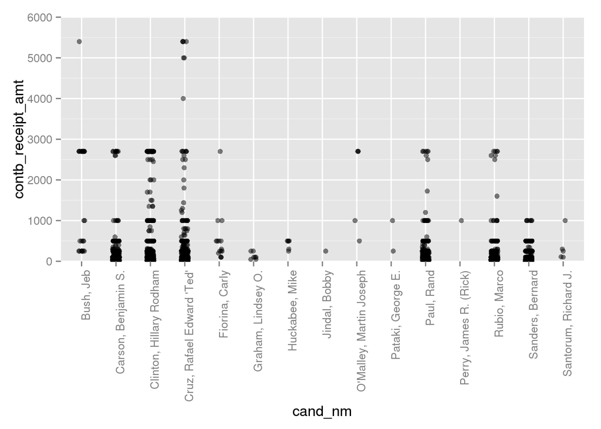

This seems to show Jeb Bush and Ted Cruz getting the contributions of the largest size. Though, even with jitter and alpha, it is difficult to compare the number and distributions made to each candidate.

We can also look at the mean donation amounts by candidate.

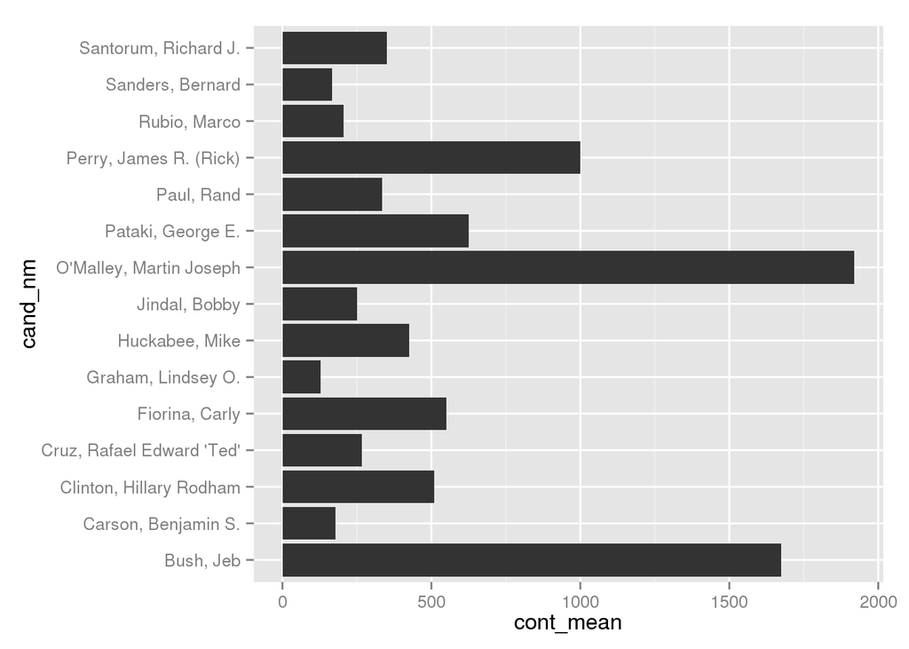

There is a wide variation between the means of the different candidates and this is something we will have to look at more.

Does the distribution of the contribution amount vary by candidate?

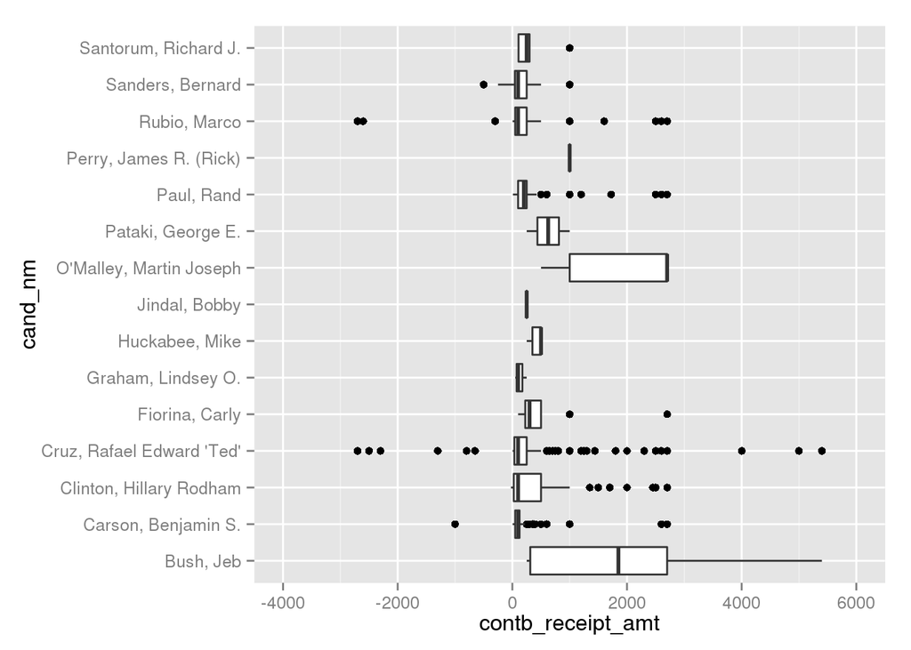

Obviously there is a lot of variation there. I want to know what is causing this. I wonder if the number of contributions effects the distributions. The cand_since feature may also be of interest here. First though, I want to look at the distributions by party.

### Contribution amount by party

First let’s check the mean, mode and median of contribution amounts by each party.

```
## Source: local data frame [3 x 4]
##
##    cand_party cont_mean cont_mode median
## 1  Democratic  520.7293      2700    100
## 2 Independent  166.2878       250    100
## 3  Republican  264.3102       100    100
```

The median is the same for each party although there are much greater differences in the mean and the mode with the Democratic party having much higher values for both.

The mean by party in plot form:

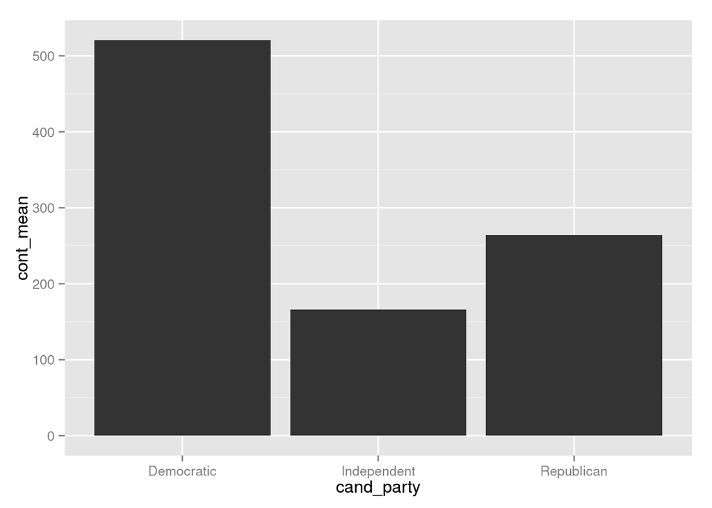

It is interesting to compare the mean, to the number of contributions by party (in the previous section) and the total amount contributed to each party.

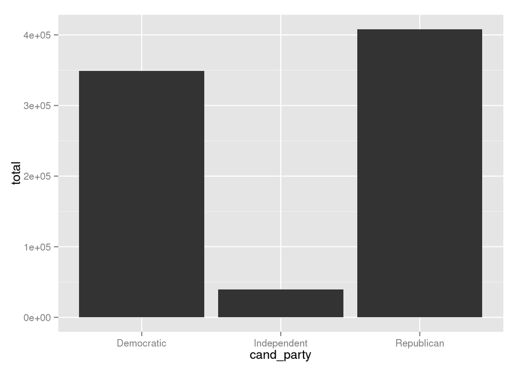

The Republican party have a much higher number of contributions, however the Democratic party have a much higher mean value. The total contributions for the two parties are relatively close.

I want to look at the distribution of the amounts by party.

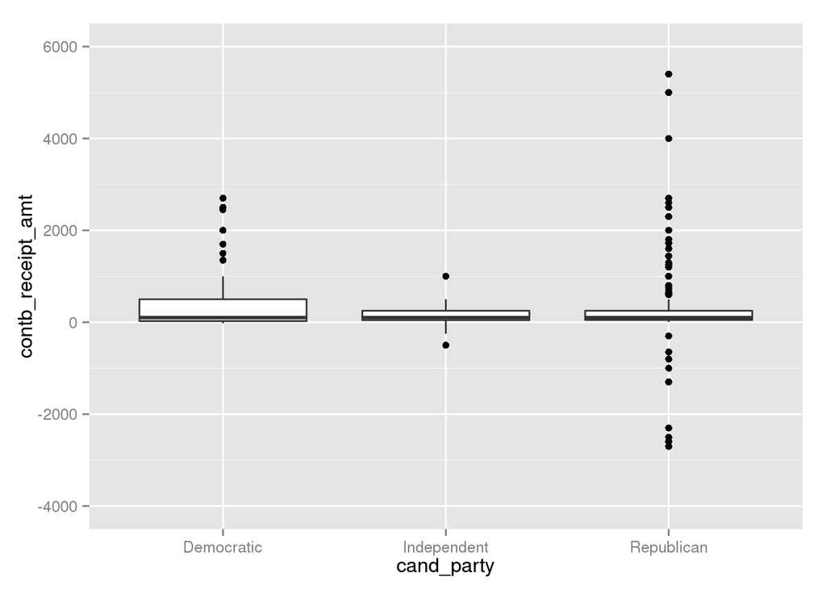

Let’s look at that again without so many outliers

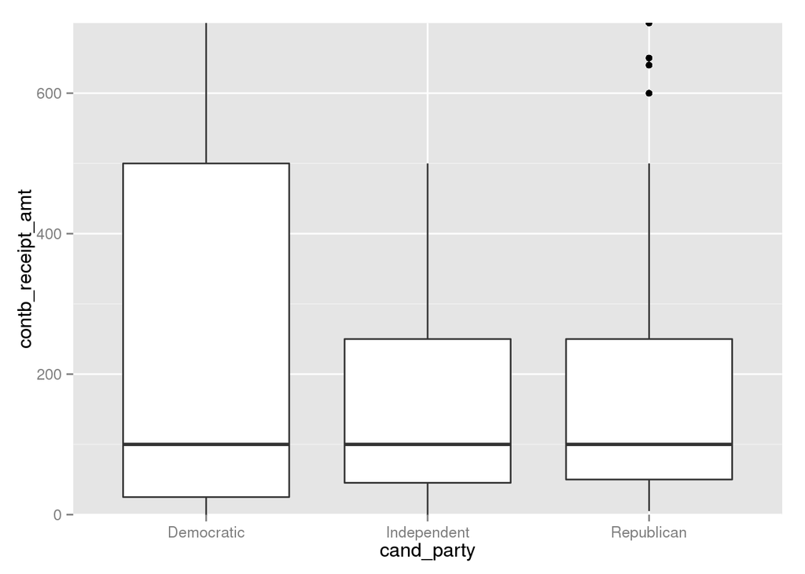

There does seem to be a noticable difference in the distribution of Democratic and Republican contributions here. There is only one independent candidate so we should take care comparing that distribution to the others.

Let’s have a look at the same data in a different plot.

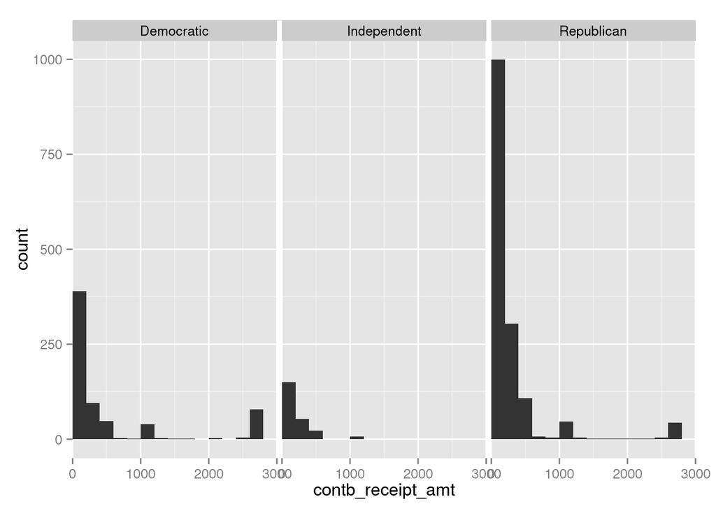

Let’s change the bin size.

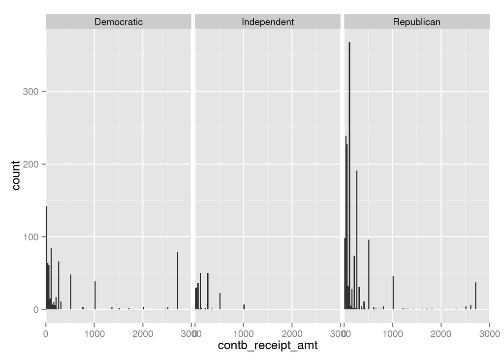

The distributions still seem simlar but we can see that the democratic contributions spike on the far left and the far right of the plot while the republican contributions peak a little away from the left of the plot.

Let’s try a third way of looking at this.

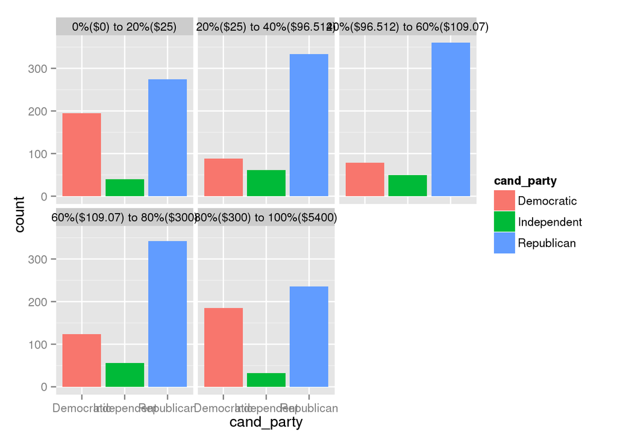

Once again, we are finding a difference in the distribution. This time much more pronounced. The republican party is getting more donations in the center of the distribution while the democratic party are getting less contributions in the center but more at the top and bottom 20% of contribution amount.

### Contribution amount by time

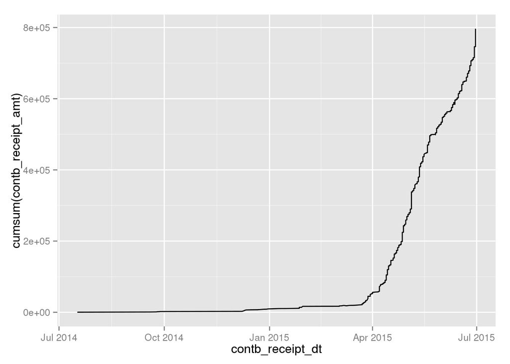

Nothing really surprising here.

### How Occupations contribute by Party

Here are the 25 most common occupations in our dataset, the number of total contributions each occupation has made and which party the contributions were for.

```
##    contbr_occupation dem ind rep
## 1         ACCOUNTANT   8   5   7
## 2           ATTORNEY  43  15  28
## 3             BANKER  12   0   4
## 4     BUSINESS OWNER   1   3  12
## 5                CEO   5   0  11
## 6       CONSTRUCTION   4   0   7
## 7         CONSULTANT   8   1  13
## 8           DISABLED  14   0   3
## 9           ENGINEER   7   2  35
## 10         EXECUTIVE   8   0  13
## 11         HOMEMAKER   7   0  52
## 12           MANAGER   1   4  14
## 13      NOT EMPLOYED  14  47   1
## 14             OWNER   7   0  40
## 15            PACKER   0   0  16
## 16  PFRESH ASSISTANT  13   0   0
## 17         PHYSICIAN  43   0  35
## 18         PRESIDENT   6   0  14
## 19         PROFESSOR  28   7   7
## 20   PROGRAM MANAGER  16   0   2
## 21           RETIRED  83  10 545
## 22             SALES  24   0  19
## 23     SELF EMPLOYED   0   0  18
## 24           TEACHER  12   4   8
## 25      VETERINARIAN   1   5   5
```

Here is a chart showing the percentage of each occupations contributions to each party.

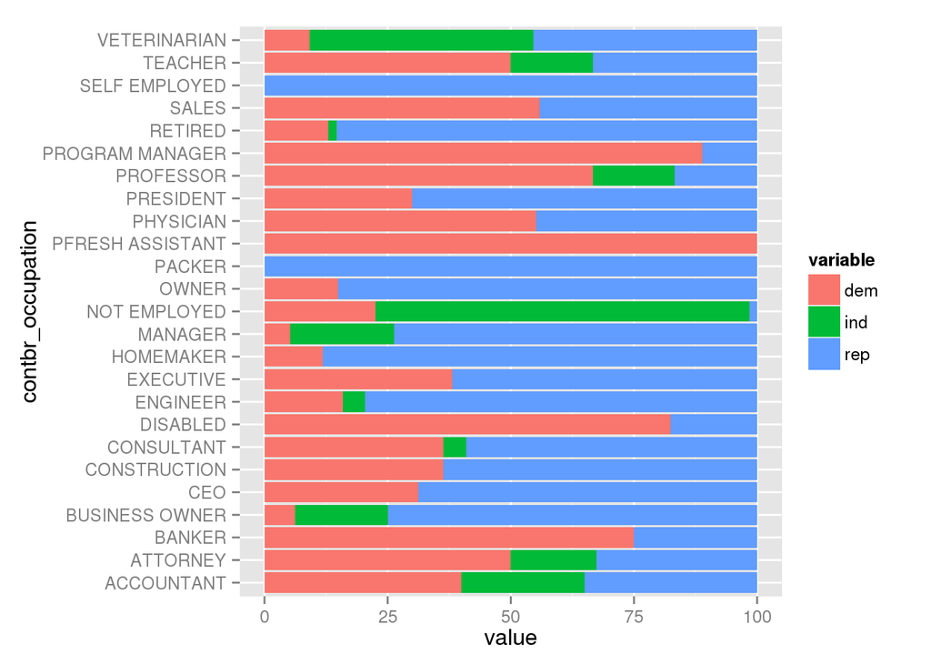

There is a lot of variation by occupation. Some occupations, such as physicians, are quite balanced in which party they contribute to. Other occupations are skewed very highly to the democratic party (bankers), republican party (engineers) or the independent candidate (not employed). I find these interesting as a number of them contradict my own stereotypes about who is likely to vote for which party.

### How Employers vary by contributions to each Party

```
##                           contbr_employer dem ind rep
## 1                           AIRXPERTS LLC   0   0  10
## 2                            BLICK CLINIC   0  10   0
## 3              CHEMICAL ABSTRACTS SERVICE   0   0   9
## 4                      CLASSIC AUTO GROUP  22   0   0
## 5                           HAWKEN SCHOOL   9   0   0
## 6                     HILLARY FOR AMERICA   9   0   0
## 7        HOLZFASTER CECIL MCKNIGHT & MUES   0   0  19
## 8                               HOMEMAKER   0   0  45
## 9  INFORMATION REQUESTED PER BEST EFFORTS   0   0 127
## 10                         JPMORGAN CHASE  12   0   0
## 11       MILES RUBBER AND PACKING COMPANY   0   0  16
## 12                MORRIS FURNITURE CO INC   0   0   9
## 13                                    N/A 118   1  21
## 14                                    NES  17   0   0
## 15                                   NONE   0   2  42
## 16                           NOT EMPLOYED  37  55   0
## 17                  OHIO STATE UNIVERSITY  10   3   0
## 18                          OHIO TURNPIKE   0   0   9
## 19                               PARALLON   9   0   0
## 20                                RETIRED  27   7 495
## 21                      SALLAH PROPERTIES   0   0  10
## 22                                   SELF   1   0  42
## 23                          SELF EMPLOYED   0   0  27
## 24                          SELF-EMPLOYED  54  10  59
## 25                            TARGET CORP  13   0   0
```

Here is a chart showing the percentage of contributions to each party from employees of the twenty five most common employers.

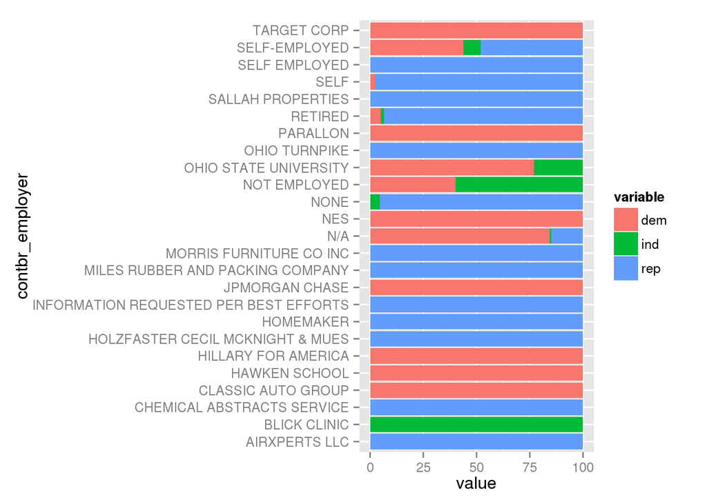

### Contributions to each party by city.

Here is a the same chart, this time showing the percentage of contributions to each party from the most common cities in the dataset.

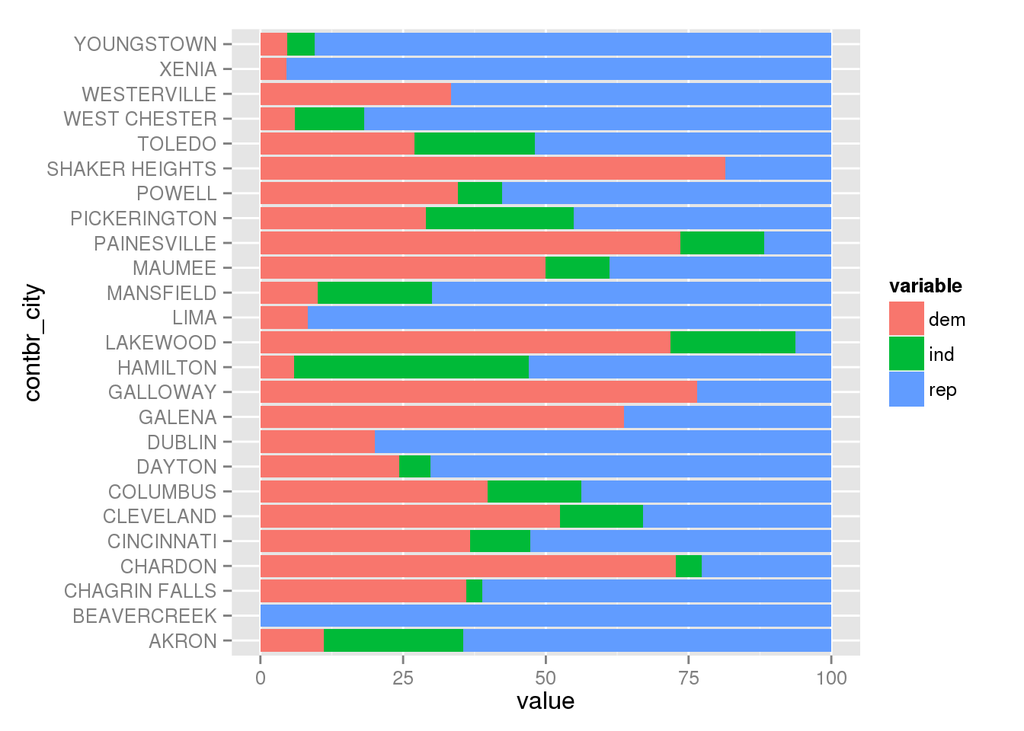

Again, there is a lot of variety between the cities with some cities contributing more to different parties by quite large quantities. I am not familiar with the geography of Ohio so there is not much I can suggest about these. It would be interesting to look at other aspects of the cities for instance population, average income or house prices to see if there are any relationships. However, that is beyond the scope of this project.